# 1-voxel Boundaries for Fat

25.11.2021

## Read BASE, SAT, VAT images

All images have the same size: 560x560x1 and consists of the same number of voxels: 313,600.

Print RLE (Run Length Encoding, kodowanie długości serii) for BASE image.

```
#> BASE: Run Length Encoding
#> BASE:   lengths: int [1:141430] 51688 2 14 3 1 1 2 3 3 4 ...
#> BASE:   values : int [1:141430] 0 4 0 4 0 4 0 4 0 4 ...
```

gdzie `lengths` to licznik powtórzeń wartości voxela, `values` – wartość voxela.

Pierwsze 100,000+ voxeli, to dół obrazu (plecy). Na naszych obrazach to tło.

## Voxel values (intensities) of images

Convert BASE, SAT, VAT images to vectors.

```r
base_intensities1 <- get_distinct_gray(base)
sat_intensities1 <- get_distinct_gray_from_border1(sat)
vat_intensities1 <- get_distinct_gray_from_border1(vat)

base_intensities <- image_to_vector(base) # all values from BASE
sat_intensities <- image_to_vector(sat)   # all values from SAT
vat_intensities <- image_to_vector(vat)   # all values from VAT
```

Print, the first ten, unique voxel values sorted into ascending order.

```r
str(base_intensities1)
```

```
#>  int [1:368] 0 4 9 14 19 24 29 34 39 43 ...
```

```r
str(c(0, base_intensities1[102:368]))
```

```
#>  num [1:268] 0 493 498 503 508 512 517 522 527 532 ...
```

```r
str(sat_intensities1)
```

```
#>  int [1:114] 0 493 498 503 508 512 517 522 527 532 ...
```

```r
str(c(0, base_intensities1[45:368]))
```

```
#>  num [1:325] 0 214 219 224 229 234 239 244 249 254 ...
```

```r
str(vat_intensities1)
```

```
#>  int [1:175] 0 214 229 234 239 244 249 254 258 263 ...
```

## Contingency tables of voxel values counts

SAT contingency table.

```
#> sat_intensities
#>      0    493    498    503    508    512    517    522    527    532    537
#> 298800      1     42     52     54     43     47     35     48     50     49
#>    542    547    552    556    561    566    571    576    581    586    591
#>     47     47     43     57     43     44     50     46     40     64     43
#>    596    600    605    610    615    620    625    630    635    640    644
#>     42     47     50     53     53     59     46     57     52     51     51
#>    649    654    659    664    669    674    679    683    688    693    698
#>     47     53     50     48     56     54     66     52     59     66     50
#>    703    708    713    718    723    727    732    737    742    747    752
#>     57     69     62     71     69     75     72     83     83     58     64
#>    757    762    767    771    776    781    786    791    796    801    806
#>     63     69     76     67     82     79     72     82     77     89     97
#>    811    815    820    825    830    835    840    845    850    854    859
#>     82     98     91     79     77     82     93     92     82     85     87
```

[output cut: 22 more lines]

VAT contingency table.

```
#> vat_intensities
#>      0    214    229    234    239    244    249    254    258    263    268
#> 303788      1      1      2      1      1      2      1      2      1      1
#>    273    278    283    288    293    298    302    307    312    317    322
#>      4      2      2      5      3      2      2      2      5      8      4
#>    327    332    337    341    346    351    356    361    366    371    376
#>      7      3      6      6      8     10      9      8      8     17     16
#>    381    385    390    395    400    405    410    415    420    425    429
#>     17     14     16     16     22     16     21     24     14     30     17
#>    434    439    444    449    454    459    464    469    473    478    483
#>     17     20     23     27     30     31     42     32     32     35     32
#>    488    493    498    503    508    512    517    522    527    532    537
#>     31     43     48     45     36     42     28     30     39     46     47
#>    542    547    552    556    561    566    571    576    581    586    591
#>     43     46     45     54     50     49     55     54     54     53     46
```

[output cut: 32 more lines]

## BASE (all voxels)

Bardzo dziwne jest to, że w obrazie jest dużo voxeli o wartościach, np. 214 (razem 1097), 219 (1030), 224 (971), 229 (940) itd., a brakuje wartości pośrednich 215, 216, 217, 218, 220, 221, 222, 223, itd.

Wygląda to tak, jak by w losowej próbie pacjentów były tylko osoby z BMI: 12, 16, 20, 24, 28. Oczywiście, może się zdarzyć, że brakuje wartości pośrednich, jeśli próba jest mała. Przykładowo, w obrazie BASE jest tak dla wartości bliskich wartości maksymalnej 1861: 1739 (3), 1749 (2), 1758 (1), …, 1832 (1), 1856 (1) 1861 (1).

```
#> base_intensities
#>      0      4      9     14     19     24     29     34     39     43     48
#> 165602  14250   7279   4438   2983   2158   1605   1225    972    860    725
#>     53     58     63     68     73     78     83     87     92     97    102
#>    645    575    599    544    513    524    531    531    527    516    464
#>    107    112    117    122    127    131    136    141    146    151    156
#>    481    487    478    506    479    541    572    625    608    684    762
#>    161    166    170    175    180    185    190    195    200    205    210
#>    834    879    877   1003    980   1023   1104   1093   1076   1075   1118
#>    214    219    224    229    234    239    244    249    254    258    263
#>   1097   1030    971    940    884    818    894    822    793    752    692
#>    268    273    278    283    288    293    298    302    307    312    317
#>    743    675    687    737    716    714    725    765    817    789    857
#>    322    327    332    337    341    346    351    356    361    366    371
#>    858    839    868    878    854    839    783    820    877    790    739
```

[output cut: 54 more lines]

## Gray bat illusion image for SAT (top) and VAT (bottom)

```r
illusion_dcm = dcm_read("illusion3/underweight_1264707_sat_vat.dcm")
```

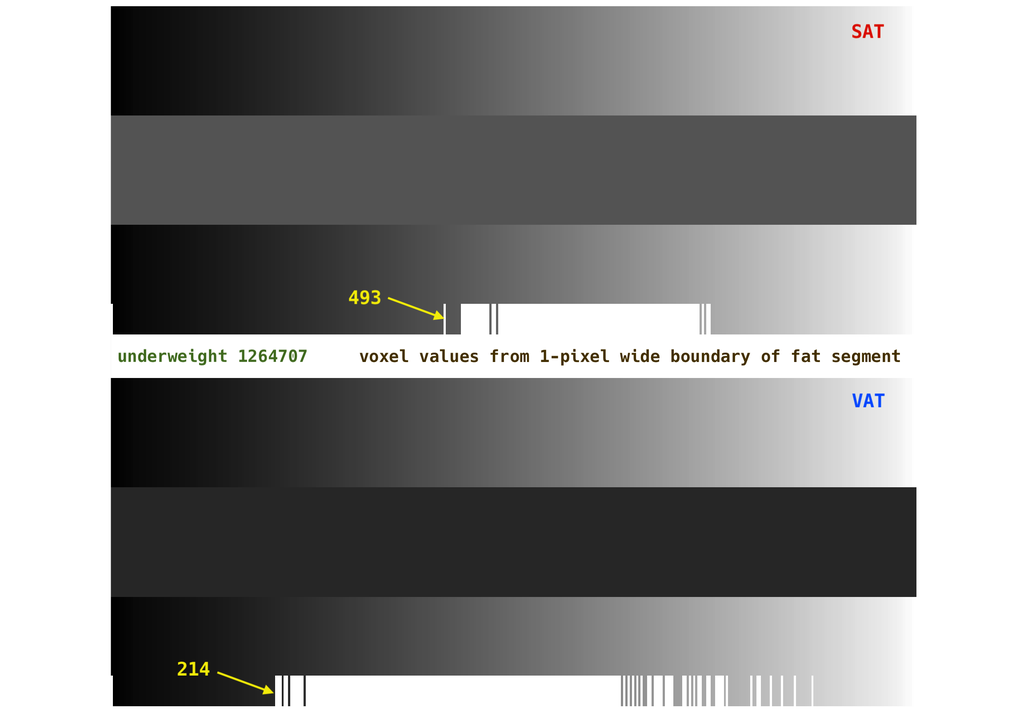

underweight, patient 1264707